# Lab 9: Testing functions, and string basics

Stat 133, Fall 2018

Nabeil Kizilbash

# Part 2, Basics of String Manipulation

```r
head(USArrests)
```

```
##            Murder Assault UrbanPop Rape
## Alabama      13.2     236       58 21.2
## Alaska       10.0     263       48 44.5
## Arizona       8.1     294       80 31.0
## Arkansas      8.8     190       50 19.5
## California    9.0     276       91 40.6
## Colorado      7.9     204       78 38.7
```

```r
states <- rownames(USArrests)
head(states)
```

```
## [1] "Alabama"    "Alaska"     "Arizona"    "Arkansas"   "California"
## [6] "Colorado"
```

```r
nchar(states)
```

```
##  [1]  7  6  7  8 10  8 11  8  7  7  6  5  8  7  4  6  8  9  5  8 13  8  9
## [24] 11  8  7  8  6 13 10 10  8 14 12  4  8  6 12 12 14 12  9  5  4  7  8
## [47] 10 13  9  7
```

```r
tolower(states)
```

```
##  [1] "alabama"        "alaska"         "arizona"        "arkansas"
##  [5] "california"     "colorado"       "connecticut"    "delaware"
##  [9] "florida"        "georgia"        "hawaii"         "idaho"
## [13] "illinois"       "indiana"        "iowa"           "kansas"
## [17] "kentucky"       "louisiana"      "maine"          "maryland"
## [21] "massachusetts"  "michigan"       "minnesota"      "mississippi"
## [25] "missouri"       "montana"        "nebraska"       "nevada"
## [29] "new hampshire"  "new jersey"     "new mexico"     "new york"
## [33] "north carolina" "north dakota"   "ohio"           "oklahoma"
## [37] "oregon"         "pennsylvania"   "rhode island"   "south carolina"
## [41] "south dakota"   "tennessee"      "texas"          "utah"
## [45] "vermont"        "virginia"       "washington"     "west virginia"
## [49] "wisconsin"      "wyoming"
```

```r
toupper(states)
```

```
##  [1] "ALABAMA"        "ALASKA"         "ARIZONA"        "ARKANSAS"
##  [5] "CALIFORNIA"     "COLORADO"       "CONNECTICUT"    "DELAWARE"
##  [9] "FLORIDA"        "GEORGIA"        "HAWAII"         "IDAHO"
## [13] "ILLINOIS"       "INDIANA"        "IOWA"           "KANSAS"
## [17] "KENTUCKY"       "LOUISIANA"      "MAINE"          "MARYLAND"
## [21] "MASSACHUSETTS"  "MICHIGAN"       "MINNESOTA"      "MISSISSIPPI"
## [25] "MISSOURI"       "MONTANA"        "NEBRASKA"       "NEVADA"
## [29] "NEW HAMPSHIRE"  "NEW JERSEY"     "NEW MEXICO"     "NEW YORK"
## [33] "NORTH CAROLINA" "NORTH DAKOTA"   "OHIO"           "OKLAHOMA"
## [37] "OREGON"         "PENNSYLVANIA"   "RHODE ISLAND"   "SOUTH CAROLINA"
## [41] "SOUTH DAKOTA"   "TENNESSEE"      "TEXAS"          "UTAH"
## [45] "VERMONT"        "VIRGINIA"       "WASHINGTON"     "WEST VIRGINIA"
## [49] "WISCONSIN"      "WYOMING"
```

```r
casefold(states)
```

```
##  [1] "alabama"        "alaska"         "arizona"        "arkansas"
##  [5] "california"     "colorado"       "connecticut"    "delaware"
##  [9] "florida"        "georgia"        "hawaii"         "idaho"
## [13] "illinois"       "indiana"        "iowa"           "kansas"
## [17] "kentucky"       "louisiana"      "maine"          "maryland"
## [21] "massachusetts"  "michigan"       "minnesota"      "mississippi"
## [25] "missouri"       "montana"        "nebraska"       "nevada"
## [29] "new hampshire"  "new jersey"     "new mexico"     "new york"
## [33] "north carolina" "north dakota"   "ohio"           "oklahoma"
## [37] "oregon"         "pennsylvania"   "rhode island"   "south carolina"
## [41] "south dakota"   "tennessee"      "texas"          "utah"
## [45] "vermont"        "virginia"       "washington"     "west virginia"
## [49] "wisconsin"      "wyoming"
```

```r
num_chars <- nchar(states)
num_chars
```

```
##  [1]  7  6  7  8 10  8 11  8  7  7  6  5  8  7  4  6  8  9  5  8 13  8  9
## [24] 11  8  7  8  6 13 10 10  8 14 12  4  8  6 12 12 14 12  9  5  4  7  8
## [47] 10 13  9  7
```

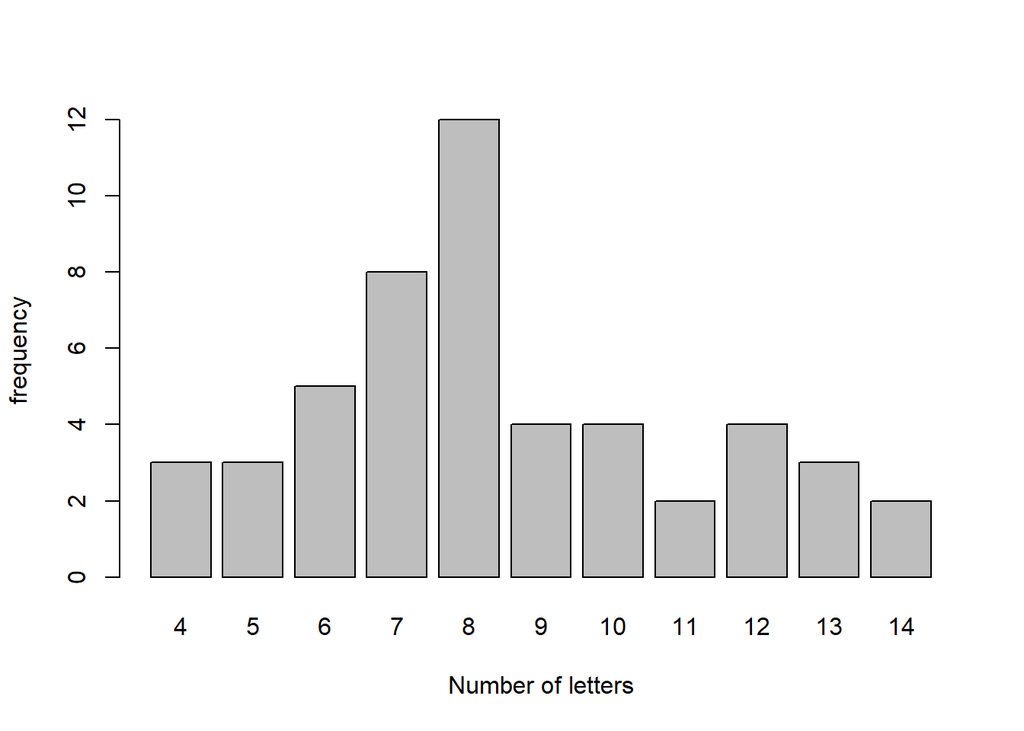

```r
char_freqs<- table(num_chars)




barplot(char_freqs, xlab = "Number of letters",ylab = "frequency" )
```

## Pasting Strings

```r
paste('pumpkin', 'pie')
```

```
## [1] "pumpkin pie"
```

You can give it any number of vector inputs

```r
paste('a', 'b', 'c', 'd', 'e')
```

```
## [1] "a b c d e"
```

You can change the separator with `sep`

```r
paste('a', 'b', 'c', 'd', 'e', sep = '-')
```

```
## [1] "a-b-c-d-e"
```

`paste()` is vectorized:

```r
paste('a', 1:5, sep = '.')
```

```
## [1] "a.1" "a.2" "a.3" "a.4" "a.5"
```

```r
# paste0() -vs- paste(..., sep = "")
paste0('Pumpkin', 'Pie')
```

```
## [1] "PumpkinPie"
```

```r
paste('Pumpkin', 'Pie', sep = '')
```

```
## [1] "PumpkinPie"
```

```r
# paste0() is also vectorized
paste0('a', 1:5)
```

```
## [1] "a1" "a2" "a3" "a4" "a5"
```

```r
head(num_chars)
```

```
## [1]  7  6  7  8 10  8
```

```r
paste(head(states,5), head(num_chars,5), sep =  " = ")
```

```
## [1] "Alabama = 7"     "Alaska = 6"      "Arizona = 7"     "Arkansas = 8"
## [5] "California = 10"
```

```r
paste(head(states,5), collapse = "")
```

```
## [1] "AlabamaAlaskaArizonaArkansasCalifornia"
```

# Permutations

210 Permutations can be formed using all the given letters in the word Alabama. 7!/4! = 210

# Substrings

```r
# extract first 3 characters
substr('Berkeley', 1, 3)
```

```
## [1] "Ber"
```

```r
substr(states, 1, 3)
```

```
##  [1] "Ala" "Ala" "Ari" "Ark" "Cal" "Col" "Con" "Del" "Flo" "Geo" "Haw"
## [12] "Ida" "Ill" "Ind" "Iow" "Kan" "Ken" "Lou" "Mai" "Mar" "Mas" "Mic"
## [23] "Min" "Mis" "Mis" "Mon" "Neb" "Nev" "New" "New" "New" "New" "Nor"
## [34] "Nor" "Ohi" "Okl" "Ore" "Pen" "Rho" "Sou" "Sou" "Ten" "Tex" "Uta"
## [45] "Ver" "Vir" "Was" "Wes" "Wis" "Wyo"
```

```r
substr(states, nchar(states) - 2, nchar(states))
```

```
##  [1] "ama" "ska" "ona" "sas" "nia" "ado" "cut" "are" "ida" "gia" "aii"
## [12] "aho" "ois" "ana" "owa" "sas" "cky" "ana" "ine" "and" "tts" "gan"
## [23] "ota" "ppi" "uri" "ana" "ska" "ada" "ire" "sey" "ico" "ork" "ina"
## [34] "ota" "hio" "oma" "gon" "nia" "and" "ina" "ota" "see" "xas" "tah"
## [45] "ont" "nia" "ton" "nia" "sin" "ing"
```

# How would you shorten the state names using the first letter and the last 3-letters?

What I would do is i would first extract the first letter, then the last 3 letters, then concatonate them together so that the full string is formed.

### Challenge

We already obtained a frequency table `char_freqs` with the counts of state names by number of characters. You can use those frequencies to get those state-names with 4-characters or 10-characters:

```r
# 4-char states
states[num_chars == 4]
```

```
## [1] "Iowa" "Ohio" "Utah"
```

```r
# 10-char states
states[num_chars == 10]
```

```
## [1] "California" "New Jersey" "New Mexico" "Washington"
```

You can use `paste()` to join the 4-character states in one single string (i.e. *collapsing*) like this—separated by a comma and space—:

```r
# collapse 4-char states
paste(states[num_chars == 4], collapse = ", ")
```

```
## [1] "Iowa, Ohio, Utah"
```

## Converting from Fahrenheit Degrees

Here are four functions that convert from Fahrenheit degrees to other temperature scales:

```r
to_celsius <- function(x = 1) {
  (x - 32) * (5/9)
}
to_kelvin <- function(x = 1) {
  (x + 459.67) * (5/9)
}
to_reaumur <- function(x = 1) {
  (x - 32) * (4/9)
}
to_rankine <- function(x = 1) {
  x + 459.67
}
```

We can use the previous functions to create a more general function `temp_convert()`:

```r
temp_convert <- function(x = 1, to = "celsius") {
  switch(tolower(to),
         "celsius" = to_celsius(x),
         "kelvin" = to_kelvin(x),
         "reaumur" = to_reaumur(x),
         "rankine" = to_rankine(x))
}
temp_convert(30, 'celsius')
```

```
## [1] -1.111111
```

`temp_convert()` works fine when the argument `to = 'celsius'`. But what happens if you try `temp_convert(30, 'Celsius')` or `temp_convert(30, 'CELSIUS')`?

**Your turn**. Rewrite `temp_convert()` such that the argument `to` can be given in upper or lower case letters. For instance, the following three calls should be equivalent:

MOdify the function to take any input and convert it to lowercase.

```r
temp_convert(30, 'celsius')
temp_convert(30, 'Celsius')
temp_convert(30, 'CELSIUS')
```

## Names of files

Imagine that you need to generate the names of 10 data `.csv` files. All the files have the same prefix name but each of them has a different number: `file1.csv`, `file2.csv`, … , `file10.csv`.

How can you generate a character vector with these names in R? Come up with at least three different ways to get such a vector:

```r
#Use the substring function to select everything except the last 3 characters, so everything except for the .csv portion of the filenmae

#Extract just the number by excluding the file portion of the file names.

#Do a for loop and only take the part of the filenamethat is a number, that way you are only getting the unique part of each filename
```

Now imagine that you need to rename the characters `file` into `dataset`. In other words, you want the vector of file names to look like this: `dataset1.csv`, `dataset2.csv`, … , `dataset10.csv`. Take the previous vector of file names and rename its elements:

```r
# rename vector of file names by using the substr function to replace the characters at the beginning of the string with dataset.
```

## Using function `cat()`

Run the following code:

```r
# name of output file
outfile <- "output.txt"
# writing to 'outfile.txt'
cat("title: Lab 09
author: Nabeil Kizilbash
date: 10/27/2018
output: html_document", file = outfile)
# insert new line
cat("\n", file = outfile, append = TRUE)
cat("A 2nd line", file = "output.txt", append = TRUE)
# insert 2 new lines
cat("\n\n", file = outfile, append = TRUE)
cat("\nThe quick brown fox jumps over the lazy dog\n",
    file = outfile, append = TRUE)
```

## Valid Color Names

The function `colors()` returns a vector with the names (in English) of 657 colors available in R. Write a function `is_color()` to test if a given name—in English—is a valid R color. If the provided name is a valid R color, `is_color()` returns `TRUE`. If the provided name is not a valid R color `is_color()` returns `FALSE`.

```r
# your is_color() function
vec <- colors()


#' Color checker
#'
#' @param color
#'
#' @return true or false
#' @purpose checks whether or not a function is a color in r
is_color <- function(color){

  if(color %in% vec){ TRUE}

  else{FALSE}




}
# test it:
is_color('yellow')  # TRUE
is_color('blu')     # FALSE
is_color('turkuoise') # FALSE
```

## Plot with a valid color

Use `is_color()` to create the function `colplot()` that takes one argument `col` (the name of a color) to produce a simple scatter plot with random numbers (e.g. use `runif()` or `rnorm()` to get point coordinates).

If `col` is a valid name—say “blue”—, the scatterplot should show a title `"Testing color blue"`.

If the provided `col` is not a valid color name, e.g. “blu”, then the function must stop, showing an **error message** `"invalid color blu"`.

```r
colplot <- function(x){

  if(is_color(x)){
    plot(rnorm(100), col = x, main = "testing color")
  }

  else {stop("This is not a valid color")}

}



# this should plot
colplot('tomato')




# this stops with error message
colplot('tomate')
```